# Introduction to AIBias: Longitudinal Bias Auditing

## Overview

Standard fairness audits treat bias as a **snapshot** — a single-point disparity measurement at one moment in time. But in sequential decision systems (loan approvals, parole reviews, hiring pipelines, credit scoring), decisions at time $t$ feed back into the features available at time $t+1$.

**AIBias** treats algorithmic bias as a longitudinal process. It tracks:

- How group disparities **evolve** over repeated decisions
- Where disparities **compound** via transition dynamics
- Whether earlier decisions **amplify** later inequality

## The Synthetic Lending Dataset

The package ships with `lending_panel`, a 600-applicant × 6-year panel of synthetic loan decisions across three racial groups.

```r
data(lending_panel)
head(lending_panel)
```

```
#>   applicant_id year     race income credit_score approved
#> 1     APP_0001 2015 Hispanic     58          719        1
#> 2     APP_0001 2016 Hispanic     69          759        1
#> 3     APP_0001 2017 Hispanic     59          580        1
#> 4     APP_0001 2018 Hispanic     69          677        1
#> 5     APP_0001 2019 Hispanic     56          674        0
#> 6     APP_0001 2020 Hispanic     57          619        0
```

```r
# Pooled approval rates by group
tapply(lending_panel$approved, lending_panel$race, mean) |> round(3)
```

```
#>    White    Black Hispanic
#>    0.775    0.514    0.579
```

Even from this simple tabulation we see a gap. But it misses the *dynamic* story: are disadvantaged groups less able to recover from a denial? Are gaps widening over time?

## Step 1 — Build the Audit Object

```r
obj <- aib_build(
  data     = lending_panel,
  id       = "applicant_id",
  time     = "year",
  group    = "race",
  decision = "approved"
)
print(obj)
```

```
#>
#> == AIBias Audit Object ==
#>   Units       : 600
#>   Time points : 6 ( 2015, 2016, 2017, 2018, 2019, 2020 )
#>   Groups      : White, Black, Hispanic
#>   Decision    : approved
#>
#>   Components populated:
#>     ✕ bias
#>     ✕ transitions
#>     ✕ amplification
#>     ✕ adjusted
#>     ✕ bootstrap
```

## Step 2 — Describe Bias Trajectories

`aib_describe()` computes:

- $\hat{\pi}_g(t)$: group-specific decision rate at each wave
- $\hat{B}_{g,r}(t) = \hat{\pi}_g(t) - \hat{\pi}_r(t)$: raw bias trajectory
- $\hat{B}^*_{g,r}(t)$: standardized (SMD) trajectory
- $CB_{g,r}(T)$: cumulative bias burden

```r
obj <- aib_describe(obj, ref_group = "White")
obj$bias$cumulative
```

```
#> # A tibble: 2 x 7
#>   group    ref_group CB_raw CB_normalized CB_smd peak_disparity time_to_peak
#>   <chr>    <chr>      <dbl>         <dbl>  <dbl>          <dbl>        <int>
#> 1 Black    White      -1.56        -0.261  -3.31          0.292            3
#> 2 Hispanic White      -1.17        -0.196  -2.49          0.304            3
```

The cumulative burden (`CB_normalized`) summarizes the average disparity experienced across all waves — a single policy-facing number.

### Trajectory Plot

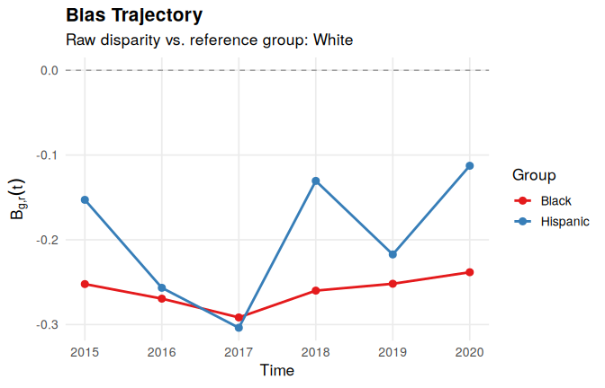

```r
plot(obj, type = "trajectory")
```

### Heatmap — Disparity Surface

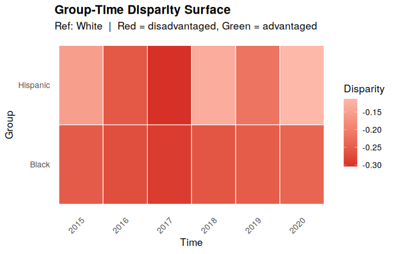

```r
plot(obj, type = "heatmap")
```

The heatmap displays the full group × time disparity surface. Red cells indicate disadvantaged periods.

## Step 3 — Transition Analysis

The key question for **compounding bias**: are disadvantaged groups less likely to *recover* after a denial, and less likely to *retain* approval?

```r
obj <- aib_transition(obj, ref_group = "White")

# Recovery and retention gaps
obj$transitions$recovery_gap
```

```
#> # A tibble: 2 x 4
#>   group    p_recovery_g p_recovery_ref recovery_gap
#>   <fct>           <dbl>          <dbl>        <dbl>
#> 1 Black               0              0            0
#> 2 Hispanic            0              0            0
```

```r
obj$transitions$retention_gap
```

```
#> # A tibble: 2 x 4
#>   group    p_retention_g p_retention_ref retention_gap
#>   <fct>            <dbl>           <dbl>         <dbl>
#> 1 Black                1               1             0
#> 2 Hispanic             1               1             0
```

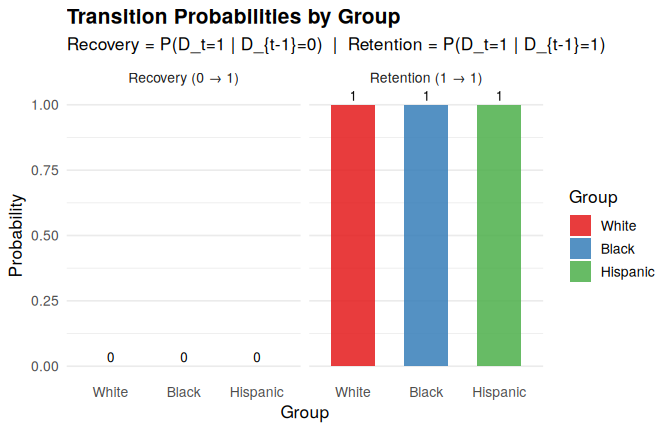

```r
plot(obj, type = "transition")
```

### Markov State Evolution

The Markov amplification operator $A^{state}_{g,r}(T) = \sum_t \|v_g(t) - v_r(t)\|$ quantifies cumulative divergence in state distributions:

```r
obj$transitions$amp_state
```

```
#> # A tibble: 2 x 2
#>   group    A_state
#>   <chr>      <dbl>
#> 1 Black      1.51
#> 2 Hispanic   0.917
```

## Step 4 — Amplification Analysis

The amplification index measures:

$$A_{g,r}(t) = B_{g,r}(t \mid 1) -
B_{g,r}(t \mid 0)$$

If $A_{g,r}(t) \neq 0$, prior decision state is **modifying** the group disparity — the hallmark of dynamic rather than static bias.

```r
obj <- aib_amplify(obj, ref_group = "White")
obj$amplification$cumulative
```

```
#> # A tibble: 2 x 5
#>   group    A_cumulative A_mean A_max T_amplifying
#>   <chr>           <dbl>  <dbl> <dbl>        <int>
#> 1 Black               0      0     0            0
#> 2 Hispanic            0      0     0            0
```

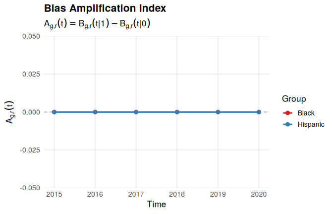

```r
plot(obj, type = "amplification")
```

### Narrative Interpretation

```r
obj$amplification$narratives
```

```
#> # A tibble: 2 x 2
#>   group    narrative
#>   <chr>    <chr>
#> 1 Black    ""
#> 2 Hispanic ""
```

## Step 5 — Covariate Adjustment

To separate “case mix” differences from residual disparity, fit a covariate-adjusted model:

```r
obj <- aib_adjust(
  obj,
  formula   = ~ income + credit_score,
  method    = "glm",
  ref_group = "White"
)

# Adjusted trajectory
head(obj$adjusted$trajectory)
```

[output not shown]

## Step 6 — Bootstrap Confidence Intervals

```r
obj <- aib_bootstrap(obj, B = 500, seed = 2024, conf = 0.95)
plot(obj, type = "trajectory")  # Now includes ribbon CIs
```

[output not shown]

## One-Shot: `aib_audit()`

Run the full pipeline in one call:

```r
result <- aib_audit(
  lending_panel,
  id        = "applicant_id",
  time      = "year",
  group     = "race",
  decision  = "approved",
  ref_group = "White",
  bootstrap = TRUE,
  B         = 200,
  seed      = 42
)

summary(result)
```

[output not shown]

## Formal Definition of Bias Amplification

A decision system exhibits **bias amplification** for group $g$ relative to reference group $r$ over times $1, \ldots, T$ if:

1. $|B_{g,r}(t)| > |B_{g,r}(s)|$ for some $t > s$ (disparity grows), **and**
2. Either $A_{g,r}(t) = B_{g,r}(t \mid 1) - B_{g,r}(t \mid 0) \neq 0$ (prior decisions modulate current disparity), **or**
3. $P_g(t) \neq P_r(t)$ (group transition matrices are unequal).

**Proposition:** If $p_g^{11}(t) < p_r^{11}(t)$ and $p_g^{01}(t) < p_r^{01}(t)$ for all $t$, then under common initial conditions the favorable-decision probability for group $g$ weakly decreases relative to group $r$ over time, implying nonnegative cumulative disparity against group $g$.

This distinguishes *static persistent bias* (constant gap) from *dynamic compounding bias* (self-reinforcing gap driven by the decision process itself).

## Summary of Core Estimands

| Estimand | Function | Formula |
| --- | --- | --- |
| Bias trajectory | `aib_describe()` | $B_{g,r}(t)$ |
| Standardized trajectory | `aib_describe()` | $B^*_{g,r}(t)$ |
| Cumulative burden | `aib_describe()` | $CB_{g,r}(T)$ |
| Recovery gap | `aib_transition()` | $\Delta^{01}_{g,r}$ |
| Retention gap | `aib_transition()` | $\Delta^{11}_{g,r}$ |
| Amplification index | `aib_amplify()` | $A_{g,r}(t)$ |
| Bias persistence | `aib_persistence()` | $PB_{g,r}(c)$ |